# Do Political Parties Matter?

Analysis of the relationship between a district preferences and the ideological position of members of congress to understand the influence of parties.

Osazi AL Khaliq

INTRODUCTION

Today, if you were to ask an average individual whether political parties within the U.S have outsized influence on elections, they would most likely answer in the affirmative. In a political climate driven by fierce polarization and cultural differences, its hard to not give responsibility to political parties for the state of our current political environment. And yet, interestingly enough, there has existed (and continues to exist) debate among congressional scholars concerning the extent to which parties matter in the U.S. Congress, assuming of course that they do. To the average person, it might seem obvious that parties matter, as the partisan line so often divides members into the “yeas” and “nays.”However, as Krehbiel (1993) notes, “In casting apparently partisan votes, do individual legislators vote with fellow party members in spite of their disagreement about the policy in question, or do they vote with fellow party members because of their agreement about the policy question?” In other words, if the party is a useful indicator of members’ true preferences, they might simply be exercising these preferences when they vote along party lines. In this case, the party is merely a label that is correlated with legislators’ preferences rather than an organization that influences and disciplines its membership. This study questions, Which is stronger in determining how a member votes: his/her party or his/her constituents? I hypothesize that there exist a strong, positive relationship between both variables in this study, supporting the argument that parties do matter within the U.S Congress.

DATA

There will be one data sources used within this study, “vote_data.” This data set will be used to provide the first dimension DW-NOMINATE scores of every member of congress which will be used to measure their ideological positions. DW-NOMINATE scores are used in this study because they act as a measure of members’ ideological position based on roll-call votes. They are created for each member by collapsing down every roll-call vote a member takes and seeing how often a member takes a liberal position on a bill versus how often a member takes a conservative position on a bill. A lower score indicates a more liberal member, and a higher score indicates a more conservative member (the scores generally range from -1 to 1). In this study, district ideology is measured using presidential vote share in the district. Specifically, each district’s average Democratic vote share from the 2012, 2016, and 2020 Presidential elections. The dependent variable in this analysis will be each member’s DW-NOMINATE score (dimension 1). The goal of this study is to figure out how well the explanatory variables (the district’s ideology and the member’s political party) predict it. THe research design for this study is cross-sectional.

The variables included in the data set for this study are:

•district code — Congressional district number

•state abbrev — State abbreviation

•party code — Member’s party (Democrat =100 and Republican =200)

•bioname — Name of member

•nominate dim1 — First dimension of DW-NOMINATE

•nominate dim2 — Second dimension of DW-NOMINATE

•Biden20 — Biden’s district vote share in 2020

•Trump20 — Trump’s district vote share in 2020

•Clinton16 — Clinton’s district vote share in 2016

•Trump16 — Trump’s district vote share in 2016

•Obama12 — Obama’s district vote share in 2012

•Romney12 — Romney’s district vote share in 2012

RESULTS:

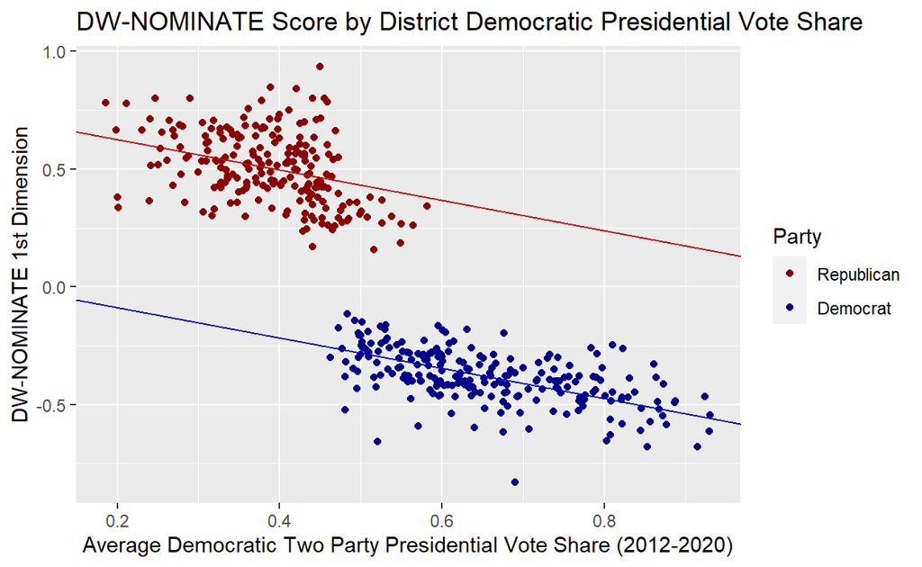

REGRESSION 1:

| Observations | 444 (1 missing obs. deleted) |
| --- | --- |
| Dependent variable | nominate_dim1 |
| Type | OLS linear regression |

| F(1,442) | 1177.39 |
| --- | --- |
| R² | 0.73 |
| Adj. R² | 0.73 |

|  | Est. | S.E. | t val. | p |
| --- | --- | --- | --- | --- |
| (Intercept) | 1.31 | 0.04 | 34.15 | 0.00 |
| Dpres_1220 | -2.40 | 0.07 | -34.31 | 0.00 |

Standard errors: OLS

REGRESSION ANALYSIS:

The intercept in the model can be interpreted as predicting a 1.31 DW-NOMINATE score for a representative in a district that had an average Democratic presidential vote share of 0%.The coefficient on Dpres_1220 predicts -2.40 decrease in DW-NOMINATE score (much more liberal) with a one unit, 0% to 100%, increase in Democratic presidential vote share. In other words, this is equivalent to a .024 decrease in DW-NOMINATE score for a one percentage point increase in Democratic presidential vote share. The Dpres_1220 coefficient is statistically significant, as the p-value is less than 0.05, so we can reject the null that the true coefficient is equal to zero.Within this regression, there is substantive significance. While the theoretical range of Republican presidential vote share is 0 to 1, the observed range is 0.070 to .814. Similarly, while the range of DW-NOMINATE is -1 to 1 the observed range is -0.831 to 0.936.

REGRESSION 2:

| Observations | 444 (1 missing obs. deleted) |
| --- | --- |
| Dependent variable | nominate_dim1 |
| Type | OLS linear regression |

| F(2,441) | 3098.96 |
| --- | --- |
| R² | 0.93 |
| Adj. R² | 0.93 |

|  | Est. | S.E. | t val. | p |
| --- | --- | --- | --- | --- |
| (Intercept) | 0.75 | 0.02 | 31.32 | 0.00 |
| Dpres_1220 | -0.64 | 0.06 | -11.02 | 0.00 |
| democrat | -0.71 | 0.02 | -37.03 | 0.00 |

Standard errors: OLS